# 주제분석 3주차 패키지_딥러닝팀(1팀)전효림

# Chapter2

# 문제1

```python
data2 = pd.read_csv('data/data2.csv')
```

```python
data2.info()
```

```
<class 'pandas.core.frame.DataFrame'>
RangeIndex: 20640 entries, 0 to 20639
Data columns (total 9 columns):
 #   Column      Non-Null Count  Dtype
---  ------      --------------  -----
 0   target      20640 non-null  float64
 1   MedInc      20640 non-null  float64
 2   HouseAge    20640 non-null  float64
 3   AveRooms    20640 non-null  float64
 4   AveBedrms   20640 non-null  float64
 5   Population  20640 non-null  float64
 6   AveOccup    20640 non-null  float64
 7   Latitude    20640 non-null  float64
 8   Longitude   20640 non-null  float64
dtypes: float64(9)
memory usage: 1.4 MB
```

```python
data2.columns
```

```
Index(['target', 'MedInc', 'HouseAge', 'AveRooms', 'AveBedrms', 'Population',
       'AveOccup', 'Latitude', 'Longitude'],
      dtype='object')
```

# 문제2

```python
y=data2['target']
X=data2.drop(['target'], axis=1)
```

```python
y= y.astype('int')
y
```

```
0        4
1        3
2        3
3        3
4        3
        ..
20635    0
20636    0
20637    0
20638    0
20639    0
Name: target, Length: 20640, dtype: int32
```

```python
from sklearn.model_selection import train_test_split

X_train, X_test, y_train, y_test=train_test_split(X,y,test_size=0.3)
```

# 문제3

Task : 데이터에 대해서 수행하고자 하는 임무를 구체화합니다. train 트레이닝일 수도 있고 predict 예측일 수도 있습니다.

application : 가장 중요한 파라미터로, 모델의 어플리케이션을 정하는데 이것이 regression 회귀분석 문제인지 또는 classification 분류 문제인지를 정합니다. Light GBM에서 디폴트는 regression 회귀분석 모델입니다.

regression: 회귀분석 binary: 이진 분류 multiclass: 다중 분류 boosting : 실행하고자 하는 알고리즘 타입을 정의합니다. 디폴트값은 gdbt 입니다.

gdbt : Traditional Gradient Boosting Decision Tree rf : Random Forest dart : Dropouts meet Multiple Additive Regression Trees goss : Gradient-based One-Side Sampling num_boost_round : boosting iteration 수로 일반적으로 100 이상입니다.

learning_rate : 최종 결과에 대한 각각의 Tree에 영향을 미치는 변수입니다. GBM은 초기의 추정값에서 시작하여 각각의Tree 결과를 사용하여 추정값을 업데이트 합니다. 학습 파라미터는 이러한 추정에서 발생하는 변화의 크기를 컨트롤합니다. 일반적인 값은 0.1, 0.001, 0.003 등등이 있습니다.

num_leaves : 전체 Tree의 leave 수 이고, 디폴트값은 31입니다.

device : 디폴트 값은 cpu 인데 gpu로 변경할 수도 있습니다.

# 문제4

```python
import lightgbm as lgb
from lightgbm import LGBMModel,LGBMRegressor
from lightgbm import LGBMClassifier
lgbm = LGBMClassifier(n_estimators=200)
# import itertools
```

```python
params = {'max_depth': [10, 15, 20],
          'min_child_samples': [20, 40, 60],
          'subsample': [0.8, 1]}

grid = GridSearchCV(lgbm, param_grid=params, scoring='neg_mean_squared_error')
grid.fit(X_train, y_train)
```

```
GridSearchCV(estimator=LGBMClassifier(n_estimators=200),
             param_grid={'max_depth': [10, 15, 20],
                         'min_child_samples': [20, 40, 60],
                         'subsample': [0.8, 1]},
             scoring='neg_mean_squared_error')
```

# 문제5

```python
grid.best_params_
```

```
{'max_depth': 20, 'min_child_samples': 60, 'subsample': 0.8}
```

```python
lgbm = LGBMClassifier(n_estimators=200, subsample=0.8,
                      min_child_samples=20, max_depth=20)

evals = [(X_test, y_test)]
lgbm.fit(X_train, y_train)
```

```
LGBMClassifier(max_depth=20, n_estimators=200, subsample=0.8)
```

# 문제6

```python
y_pred = lgbm.predict(X_test)
print("예측된 라벨:", y_pred)
print("ground-truth 라벨:", y_test)
```

```
예측된 라벨: [3 0 1 ... 0 2 1]
ground-truth 라벨: 5554     3
3193     0
18868    1
10608    2
18196    2
        ..
7626     1
8624     4
1996     0
16762    2
14269    0
Name: target, Length: 6192, dtype: int32
```

```python
print("prediction accuracy: {:.2f}".format(np.mean(y_pred == y_test)))
```

```
prediction accuracy: 0.73
```

# Chapter3 LSTM

# 문제1

```python
data3 = pd.read_csv('data/Samsung.csv')
```

# 문제2

```python
data3.info()
```

```
<class 'pandas.core.frame.DataFrame'>
RangeIndex: 627 entries, 0 to 626
Data columns (total 6 columns):
 #   Column  Non-Null Count  Dtype
---  ------  --------------  -----
 0   Date    627 non-null    object
 1   Price   627 non-null    object
 2   Open    627 non-null    object
 3   High    627 non-null    object
 4   Low     627 non-null    object
 5   Vol.    627 non-null    object
dtypes: object(6)
memory usage: 29.5+ KB
```

```python
data3["Open"] = data3["Open"].str.replace(pat=r'[^\w]', repl=r'', regex=True)
data3["High"] = data3["High"].str.replace(pat=r'[^\w]', repl=r'', regex=True)
data3["Low"] = data3["Low"].str.replace(pat=r'[^\w]', repl=r'', regex=True)
data3["Price"] = data3["Price"].str.replace(pat=r'[^\w]', repl=r'', regex=True)
```

```python
data3["Open"]= data3["Open"].astype('float')
data3["High"]= data3["High"].astype('float')
data3["Low"]= data3["Low"].astype('float')
data3["Price"]= data3["Price"].astype('float')
```

# 문제3

```python
data3['Date'] == pd.to_datetime(data3['Date'])
data3['Date']
```

```
0      2019-10-01
1      2019-10-02
2      2019-10-03
3      2019-10-04
4      2019-10-06
          ...
622    2021-10-26
623    2021-10-27
624    2021-10-28
625    2021-10-29
626    2021-10-31
Name: Date, Length: 627, dtype: object
```

```python
from datetime import datetime, timedelta
days60 = datetime.today()- timedelta(60)
days60 =days60.strftime("%Y-%m-%d")
days60
```

```
'2021-09-12'
```

```python
test = data3.iloc[567:,:]
train = data3.iloc[:566,:]
```

```python
train=train.drop(['Date','Vol.'], axis=1)
test=test.drop(['Date','Vol.'], axis=1)
```

# 문제4

```python
from sklearn.preprocessing import MinMaxScaler

min_max_scaler = MinMaxScaler()

train = min_max_scaler.fit_transform(train)
train = pd.DataFrame(train)
test = min_max_scaler.fit_transform(test)
test = pd.DataFrame(test)
train.columns=['Price','Open','High','Low']
test.columns=['Price','Open','High','Low']
```

# 문제5

```python
# https://3months.tistory.com/168
for s in range(1, 21):
    train['shift_{}'.format(s)] = train['Price'].shift(s)
    test['shift_{}'.format(s)] = test['Price'].shift(s)
test
```

|  | Price | Open | High | Low | shift_1 | shift_2 | shift_3 | shift_4 | shift_5 | shift_6 | ... | shift_11 | shift_12 | shift_13 | shift_14 | shift_15 | shift_16 | shift_17 | shift_18 | shift_19 | shift_20 |
| --- | --- | --- | --- | --- | --- | --- | --- | --- | --- | --- | --- | --- | --- | --- | --- | --- | --- | --- | --- | --- | --- |
| 0 | 0.606742 | 0.629213 | 0.679012 | 0.629213 | NaN | NaN | NaN | NaN | NaN | NaN | ... | NaN | NaN | NaN | NaN | NaN | NaN | NaN | NaN | NaN | NaN |
| 1 | 0.573034 | 0.584270 | 0.617284 | 0.528090 | 0.606742 | NaN | NaN | NaN | NaN | NaN | ... | NaN | NaN | NaN | NaN | NaN | NaN | NaN | NaN | NaN | NaN |
| 2 | 0.483146 | 0.539326 | 0.592593 | 0.528090 | 0.573034 | 0.606742 | NaN | NaN | NaN | NaN | ... | NaN | NaN | NaN | NaN | NaN | NaN | NaN | NaN | NaN | NaN |
| 3 | 0.438202 | 0.539326 | 0.530864 | 0.460674 | 0.483146 | 0.573034 | 0.606742 | NaN | NaN | NaN | ... | NaN | NaN | NaN | NaN | NaN | NaN | NaN | NaN | NaN | NaN |
| 4 | 0.438202 | 0.449438 | 0.382716 | 0.483146 | 0.438202 | 0.483146 | 0.573034 | 0.606742 | NaN | NaN | ... | NaN | NaN | NaN | NaN | NaN | NaN | NaN | NaN | NaN | NaN |
| 5 | 0.505618 | 0.516854 | 0.543210 | 0.516854 | 0.438202 | 0.438202 | 0.483146 | 0.573034 | 0.606742 | NaN | ... | NaN | NaN | NaN | NaN | NaN | NaN | NaN | NaN | NaN | NaN |
| 6 | 0.764045 | 0.584270 | 0.753086 | 0.617978 | 0.505618 | 0.438202 | 0.438202 | 0.483146 | 0.573034 | 0.606742 | ... | NaN | NaN | NaN | NaN | NaN | NaN | NaN | NaN | NaN | NaN |
| 7 | 0.775281 | 0.842697 | 0.851852 | 0.730337 | 0.764045 | 0.505618 | 0.438202 | 0.438202 | 0.483146 | 0.573034 | ... | NaN | NaN | NaN | NaN | NaN | NaN | NaN | NaN | NaN | NaN |
| 8 | 0.651685 | 0.831461 | 0.814815 | 0.696629 | 0.775281 | 0.764045 | 0.505618 | 0.438202 | 0.438202 | 0.483146 | ... | NaN | NaN | NaN | NaN | NaN | NaN | NaN | NaN | NaN | NaN |
| 9 | 0.617978 | 0.629213 | 0.666667 | 0.606742 | 0.651685 | 0.775281 | 0.764045 | 0.505618 | 0.438202 | 0.438202 | ... | NaN | NaN | NaN | NaN | NaN | NaN | NaN | NaN | NaN | NaN |
| 10 | 0.617978 | 0.629213 | 0.580247 | 0.662921 | 0.617978 | 0.651685 | 0.775281 | 0.764045 | 0.505618 | 0.438202 | ... | NaN | NaN | NaN | NaN | NaN | NaN | NaN | NaN | NaN | NaN |
| 11 | 0.651685 | 0.752809 | 0.716049 | 0.651685 | 0.617978 | 0.617978 | 0.651685 | 0.775281 | 0.764045 | 0.505618 | ... | 0.606742 | NaN | NaN | NaN | NaN | NaN | NaN | NaN | NaN | NaN |
| 12 | 0.887640 | 0.685393 | 0.876543 | 0.662921 | 0.651685 | 0.617978 | 0.617978 | 0.651685 | 0.775281 | 0.764045 | ... | 0.573034 | 0.606742 | NaN | NaN | NaN | NaN | NaN | NaN | NaN | NaN |
| 13 | 0.898876 | 0.887640 | 0.925926 | 0.842697 | 0.887640 | 0.651685 | 0.617978 | 0.617978 | 0.651685 | 0.775281 | ... | 0.483146 | 0.573034 | 0.606742 | NaN | NaN | NaN | NaN | NaN | NaN | NaN |
| 14 | 0.808989 | 0.910112 | 0.888889 | 0.820225 | 0.898876 | 0.887640 | 0.651685 | 0.617978 | 0.617978 | 0.651685 | ... | 0.438202 | 0.483146 | 0.573034 | 0.606742 | NaN | NaN | NaN | NaN | NaN | NaN |
| 15 | 0.876404 | 0.865169 | 0.876543 | 0.853933 | 0.808989 | 0.898876 | 0.887640 | 0.651685 | 0.617978 | 0.617978 | ... | 0.438202 | 0.438202 | 0.483146 | 0.573034 | 0.606742 | NaN | NaN | NaN | NaN | NaN |
| 16 | 0.876404 | 0.887640 | 0.864198 | 0.921348 | 0.876404 | 0.808989 | 0.898876 | 0.887640 | 0.651685 | 0.617978 | ... | 0.505618 | 0.438202 | 0.438202 | 0.483146 | 0.573034 | 0.606742 | NaN | NaN | NaN | NaN |
| 17 | 0.955056 | 0.910112 | 0.987654 | 0.921348 | 0.876404 | 0.876404 | 0.808989 | 0.898876 | 0.887640 | 0.651685 | ... | 0.764045 | 0.505618 | 0.438202 | 0.438202 | 0.483146 | 0.573034 | 0.606742 | NaN | NaN | NaN |
| 18 | 0.820225 | 0.943820 | 0.925926 | 0.842697 | 0.955056 | 0.876404 | 0.876404 | 0.808989 | 0.898876 | 0.887640 | ... | 0.775281 | 0.764045 | 0.505618 | 0.438202 | 0.438202 | 0.483146 | 0.573034 | 0.606742 | NaN | NaN |
| 19 | 0.842697 | 0.831461 | 0.839506 | 0.808989 | 0.820225 | 0.955056 | 0.876404 | 0.876404 | 0.808989 | 0.898876 | ... | 0.651685 | 0.775281 | 0.764045 | 0.505618 | 0.438202 | 0.438202 | 0.483146 | 0.573034 | 0.606742 | NaN |
| 20 | 0.730337 | 0.853933 | 0.864198 | 0.741573 | 0.842697 | 0.820225 | 0.955056 | 0.876404 | 0.876404 | 0.808989 | ... | 0.617978 | 0.651685 | 0.775281 | 0.764045 | 0.505618 | 0.438202 | 0.438202 | 0.483146 | 0.573034 | 0.606742 |
| 21 | 0.730337 | 0.741573 | 0.740741 | 0.719101 | 0.730337 | 0.842697 | 0.820225 | 0.955056 | 0.876404 | 0.876404 | ... | 0.617978 | 0.617978 | 0.651685 | 0.775281 | 0.764045 | 0.505618 | 0.438202 | 0.438202 | 0.483146 | 0.573034 |
| 22 | 0.730337 | 0.741573 | 0.703704 | 0.775281 | 0.730337 | 0.730337 | 0.842697 | 0.820225 | 0.955056 | 0.876404 | ... | 0.651685 | 0.617978 | 0.617978 | 0.651685 | 0.775281 | 0.764045 | 0.505618 | 0.438202 | 0.438202 | 0.483146 |
| 23 | 0.842697 | 0.719101 | 0.827160 | 0.752809 | 0.730337 | 0.730337 | 0.730337 | 0.842697 | 0.820225 | 0.955056 | ... | 0.887640 | 0.651685 | 0.617978 | 0.617978 | 0.651685 | 0.775281 | 0.764045 | 0.505618 | 0.438202 | 0.438202 |
| 24 | 0.876404 | 0.932584 | 1.000000 | 0.921348 | 0.842697 | 0.730337 | 0.730337 | 0.730337 | 0.842697 | 0.820225 | ... | 0.898876 | 0.887640 | 0.651685 | 0.617978 | 0.617978 | 0.651685 | 0.775281 | 0.764045 | 0.505618 | 0.438202 |
| 25 | 0.921348 | 0.955056 | 0.950617 | 0.910112 | 0.876404 | 0.842697 | 0.730337 | 0.730337 | 0.730337 | 0.842697 | ... | 0.808989 | 0.898876 | 0.887640 | 0.651685 | 0.617978 | 0.617978 | 0.651685 | 0.775281 | 0.764045 | 0.505618 |
| 26 | 0.820225 | 0.966292 | 0.962963 | 0.865169 | 0.921348 | 0.876404 | 0.842697 | 0.730337 | 0.730337 | 0.730337 | ... | 0.876404 | 0.808989 | 0.898876 | 0.887640 | 0.651685 | 0.617978 | 0.617978 | 0.651685 | 0.775281 | 0.764045 |
| 27 | 0.943820 | 0.853933 | 0.938272 | 0.842697 | 0.820225 | 0.921348 | 0.876404 | 0.842697 | 0.730337 | 0.730337 | ... | 0.876404 | 0.876404 | 0.808989 | 0.898876 | 0.887640 | 0.651685 | 0.617978 | 0.617978 | 0.651685 | 0.775281 |
| 28 | 0.943820 | 0.955056 | 0.938272 | 0.988764 | 0.943820 | 0.820225 | 0.921348 | 0.876404 | 0.842697 | 0.730337 | ... | 0.955056 | 0.876404 | 0.876404 | 0.808989 | 0.898876 | 0.887640 | 0.651685 | 0.617978 | 0.617978 | 0.651685 |
| 29 | 0.966292 | 0.988764 | 0.987654 | 0.955056 | 0.943820 | 0.943820 | 0.820225 | 0.921348 | 0.876404 | 0.842697 | ... | 0.820225 | 0.955056 | 0.876404 | 0.876404 | 0.808989 | 0.898876 | 0.887640 | 0.651685 | 0.617978 | 0.617978 |
| 30 | 0.955056 | 1.000000 | 1.000000 | 0.977528 | 0.966292 | 0.943820 | 0.943820 | 0.820225 | 0.921348 | 0.876404 | ... | 0.842697 | 0.820225 | 0.955056 | 0.876404 | 0.876404 | 0.808989 | 0.898876 | 0.887640 | 0.651685 | 0.617978 |
| 31 | 0.955056 | 0.966292 | 0.950617 | 1.000000 | 0.955056 | 0.966292 | 0.943820 | 0.943820 | 0.820225 | 0.921348 | ... | 0.730337 | 0.842697 | 0.820225 | 0.955056 | 0.876404 | 0.876404 | 0.808989 | 0.898876 | 0.887640 | 0.651685 |
| 32 | 1.000000 | 0.966292 | 1.000000 | 0.966292 | 0.955056 | 0.955056 | 0.966292 | 0.943820 | 0.943820 | 0.820225 | ... | 0.730337 | 0.730337 | 0.842697 | 0.820225 | 0.955056 | 0.876404 | 0.876404 | 0.808989 | 0.898876 | 0.887640 |
| 33 | 0.842697 | 1.000000 | 0.987654 | 0.876404 | 1.000000 | 0.955056 | 0.955056 | 0.966292 | 0.943820 | 0.943820 | ... | 0.730337 | 0.730337 | 0.730337 | 0.842697 | 0.820225 | 0.955056 | 0.876404 | 0.876404 | 0.808989 | 0.898876 |
| 34 | 0.595506 | 0.685393 | 0.703704 | 0.606742 | 0.842697 | 1.000000 | 0.955056 | 0.955056 | 0.966292 | 0.943820 | ... | 0.842697 | 0.730337 | 0.730337 | 0.730337 | 0.842697 | 0.820225 | 0.955056 | 0.876404 | 0.876404 | 0.808989 |
| 35 | 0.595506 | 0.629213 | 0.641975 | 0.606742 | 0.595506 | 0.842697 | 1.000000 | 0.955056 | 0.955056 | 0.966292 | ... | 0.876404 | 0.842697 | 0.730337 | 0.730337 | 0.730337 | 0.842697 | 0.820225 | 0.955056 | 0.876404 | 0.876404 |
| 36 | 0.494382 | 0.584270 | 0.543210 | 0.505618 | 0.595506 | 0.595506 | 0.842697 | 1.000000 | 0.955056 | 0.955056 | ... | 0.921348 | 0.876404 | 0.842697 | 0.730337 | 0.730337 | 0.730337 | 0.842697 | 0.820225 | 0.955056 | 0.876404 |
| 37 | 0.494382 | 0.505618 | 0.444444 | 0.539326 | 0.494382 | 0.595506 | 0.595506 | 0.842697 | 1.000000 | 0.955056 | ... | 0.820225 | 0.921348 | 0.876404 | 0.842697 | 0.730337 | 0.730337 | 0.730337 | 0.842697 | 0.820225 | 0.955056 |
| 38 | 0.382022 | 0.471910 | 0.419753 | 0.337079 | 0.494382 | 0.494382 | 0.595506 | 0.595506 | 0.842697 | 1.000000 | ... | 0.943820 | 0.820225 | 0.921348 | 0.876404 | 0.842697 | 0.730337 | 0.730337 | 0.730337 | 0.842697 | 0.820225 |
| 39 | 0.280899 | 0.449438 | 0.395062 | 0.314607 | 0.382022 | 0.494382 | 0.494382 | 0.595506 | 0.595506 | 0.842697 | ... | 0.943820 | 0.943820 | 0.820225 | 0.921348 | 0.876404 | 0.842697 | 0.730337 | 0.730337 | 0.730337 | 0.842697 |
| 40 | 0.314607 | 0.348315 | 0.308642 | 0.325843 | 0.280899 | 0.382022 | 0.494382 | 0.494382 | 0.595506 | 0.595506 | ... | 0.966292 | 0.943820 | 0.943820 | 0.820225 | 0.921348 | 0.876404 | 0.842697 | 0.730337 | 0.730337 | 0.730337 |
| 41 | 0.303371 | 0.404494 | 0.345679 | 0.348315 | 0.314607 | 0.280899 | 0.382022 | 0.494382 | 0.494382 | 0.595506 | ... | 0.955056 | 0.966292 | 0.943820 | 0.943820 | 0.820225 | 0.921348 | 0.876404 | 0.842697 | 0.730337 | 0.730337 |
| 42 | 0.303371 | 0.314607 | 0.234568 | 0.348315 | 0.303371 | 0.314607 | 0.280899 | 0.382022 | 0.494382 | 0.494382 | ... | 0.955056 | 0.955056 | 0.966292 | 0.943820 | 0.943820 | 0.820225 | 0.921348 | 0.876404 | 0.842697 | 0.730337 |
| 43 | 0.022472 | 0.235955 | 0.160494 | 0.033708 | 0.303371 | 0.303371 | 0.314607 | 0.280899 | 0.382022 | 0.494382 | ... | 1.000000 | 0.955056 | 0.955056 | 0.966292 | 0.943820 | 0.943820 | 0.820225 | 0.921348 | 0.876404 | 0.842697 |
| 44 | 0.000000 | 0.000000 | 0.000000 | 0.000000 | 0.022472 | 0.303371 | 0.303371 | 0.314607 | 0.280899 | 0.382022 | ... | 0.842697 | 1.000000 | 0.955056 | 0.955056 | 0.966292 | 0.943820 | 0.943820 | 0.820225 | 0.921348 | 0.876404 |
| 45 | 0.067416 | 0.044944 | 0.024691 | 0.044944 | 0.000000 | 0.022472 | 0.303371 | 0.303371 | 0.314607 | 0.280899 | ... | 0.595506 | 0.842697 | 1.000000 | 0.955056 | 0.955056 | 0.966292 | 0.943820 | 0.943820 | 0.820225 | 0.921348 |
| 46 | 0.146067 | 0.168539 | 0.172840 | 0.179775 | 0.067416 | 0.000000 | 0.022472 | 0.303371 | 0.303371 | 0.314607 | ... | 0.595506 | 0.595506 | 0.842697 | 1.000000 | 0.955056 | 0.955056 | 0.966292 | 0.943820 | 0.943820 | 0.820225 |
| 47 | 0.146067 | 0.157303 | 0.061728 | 0.191011 | 0.146067 | 0.067416 | 0.000000 | 0.022472 | 0.303371 | 0.303371 | ... | 0.494382 | 0.595506 | 0.595506 | 0.842697 | 1.000000 | 0.955056 | 0.955056 | 0.966292 | 0.943820 | 0.943820 |
| 48 | 0.157303 | 0.157303 | 0.086420 | 0.089888 | 0.146067 | 0.146067 | 0.067416 | 0.000000 | 0.022472 | 0.303371 | ... | 0.494382 | 0.494382 | 0.595506 | 0.595506 | 0.842697 | 1.000000 | 0.955056 | 0.955056 | 0.966292 | 0.943820 |
| 49 | 0.202247 | 0.235955 | 0.172840 | 0.224719 | 0.157303 | 0.146067 | 0.146067 | 0.067416 | 0.000000 | 0.022472 | ... | 0.382022 | 0.494382 | 0.494382 | 0.595506 | 0.595506 | 0.842697 | 1.000000 | 0.955056 | 0.955056 | 0.966292 |
| 50 | 0.168539 | 0.235955 | 0.172840 | 0.202247 | 0.202247 | 0.157303 | 0.146067 | 0.146067 | 0.067416 | 0.000000 | ... | 0.280899 | 0.382022 | 0.494382 | 0.494382 | 0.595506 | 0.595506 | 0.842697 | 1.000000 | 0.955056 | 0.955056 |
| 51 | 0.157303 | 0.179775 | 0.123457 | 0.179775 | 0.168539 | 0.202247 | 0.157303 | 0.146067 | 0.146067 | 0.067416 | ... | 0.314607 | 0.280899 | 0.382022 | 0.494382 | 0.494382 | 0.595506 | 0.595506 | 0.842697 | 1.000000 | 0.955056 |
| 52 | 0.179775 | 0.146067 | 0.135802 | 0.179775 | 0.157303 | 0.168539 | 0.202247 | 0.157303 | 0.146067 | 0.146067 | ... | 0.303371 | 0.314607 | 0.280899 | 0.382022 | 0.494382 | 0.494382 | 0.595506 | 0.595506 | 0.842697 | 1.000000 |
| 53 | 0.179775 | 0.191011 | 0.098765 | 0.224719 | 0.179775 | 0.157303 | 0.168539 | 0.202247 | 0.157303 | 0.146067 | ... | 0.303371 | 0.303371 | 0.314607 | 0.280899 | 0.382022 | 0.494382 | 0.494382 | 0.595506 | 0.595506 | 0.842697 |
| 54 | 0.157303 | 0.146067 | 0.123457 | 0.123596 | 0.179775 | 0.179775 | 0.157303 | 0.168539 | 0.202247 | 0.157303 | ... | 0.022472 | 0.303371 | 0.303371 | 0.314607 | 0.280899 | 0.382022 | 0.494382 | 0.494382 | 0.595506 | 0.595506 |
| 55 | 0.258427 | 0.202247 | 0.234568 | 0.224719 | 0.157303 | 0.179775 | 0.179775 | 0.157303 | 0.168539 | 0.202247 | ... | 0.000000 | 0.022472 | 0.303371 | 0.303371 | 0.314607 | 0.280899 | 0.382022 | 0.494382 | 0.494382 | 0.595506 |
| 56 | 0.146067 | 0.258427 | 0.172840 | 0.179775 | 0.258427 | 0.157303 | 0.179775 | 0.179775 | 0.157303 | 0.168539 | ... | 0.067416 | 0.000000 | 0.022472 | 0.303371 | 0.303371 | 0.314607 | 0.280899 | 0.382022 | 0.494382 | 0.494382 |
| 57 | 0.213483 | 0.101124 | 0.308642 | 0.123596 | 0.146067 | 0.258427 | 0.157303 | 0.179775 | 0.179775 | 0.157303 | ... | 0.146067 | 0.067416 | 0.000000 | 0.022472 | 0.303371 | 0.303371 | 0.314607 | 0.280899 | 0.382022 | 0.494382 |
| 58 | 0.112360 | 0.280899 | 0.246914 | 0.146067 | 0.213483 | 0.146067 | 0.258427 | 0.157303 | 0.179775 | 0.179775 | ... | 0.146067 | 0.146067 | 0.067416 | 0.000000 | 0.022472 | 0.303371 | 0.303371 | 0.314607 | 0.280899 | 0.382022 |
| 59 | 0.112360 | 0.123596 | 0.024691 | 0.157303 | 0.112360 | 0.213483 | 0.146067 | 0.258427 | 0.157303 | 0.179775 | ... | 0.157303 | 0.146067 | 0.146067 | 0.067416 | 0.000000 | 0.022472 | 0.303371 | 0.303371 | 0.314607 | 0.280899 |

60 rows × 24 columns

```python
X_train = train.dropna().drop(['Price'], axis=1)
y_train = train.dropna()[['Price']]
X_train.head()
```

|  | Open | High | Low | shift_1 | shift_2 | shift_3 | shift_4 | shift_5 | shift_6 | shift_7 | ... | shift_11 | shift_12 | shift_13 | shift_14 | shift_15 | shift_16 | shift_17 | shift_18 | shift_19 | shift_20 |
| --- | --- | --- | --- | --- | --- | --- | --- | --- | --- | --- | --- | --- | --- | --- | --- | --- | --- | --- | --- | --- | --- |
| 20 | 0.206681 | 0.168391 | 0.171908 | 0.179381 | 0.179381 | 0.160825 | 0.152577 | 0.152577 | 0.164948 | 0.169072 | ... | 0.137113 | 0.124742 | 0.131959 | 0.131959 | 0.108247 | 0.113402 | 0.113402 | 0.105155 | 0.105155 | 0.130928 |
| 21 | 0.171190 | 0.143932 | 0.171908 | 0.169072 | 0.179381 | 0.179381 | 0.160825 | 0.152577 | 0.152577 | 0.164948 | ... | 0.137113 | 0.137113 | 0.124742 | 0.131959 | 0.131959 | 0.108247 | 0.113402 | 0.113402 | 0.105155 | 0.105155 |
| 22 | 0.173278 | 0.138288 | 0.180294 | 0.173196 | 0.169072 | 0.179381 | 0.179381 | 0.160825 | 0.152577 | 0.152577 | ... | 0.154639 | 0.137113 | 0.137113 | 0.124742 | 0.131959 | 0.131959 | 0.108247 | 0.113402 | 0.113402 | 0.105155 |
| 23 | 0.169102 | 0.149577 | 0.176101 | 0.173196 | 0.173196 | 0.169072 | 0.179381 | 0.179381 | 0.160825 | 0.152577 | ... | 0.156701 | 0.154639 | 0.137113 | 0.137113 | 0.124742 | 0.131959 | 0.131959 | 0.108247 | 0.113402 | 0.113402 |
| 24 | 0.183716 | 0.153340 | 0.178197 | 0.181443 | 0.173196 | 0.173196 | 0.169072 | 0.179381 | 0.179381 | 0.160825 | ... | 0.169072 | 0.156701 | 0.154639 | 0.137113 | 0.137113 | 0.124742 | 0.131959 | 0.131959 | 0.108247 | 0.113402 |

5 rows × 23 columns

```python
X_test = test.dropna().drop(['Price'], axis=1)
y_test = test.dropna()[['Price']]
X_test
```

|  | Open | High | Low | shift_1 | shift_2 | shift_3 | shift_4 | shift_5 | shift_6 | shift_7 | ... | shift_11 | shift_12 | shift_13 | shift_14 | shift_15 | shift_16 | shift_17 | shift_18 | shift_19 | shift_20 |
| --- | --- | --- | --- | --- | --- | --- | --- | --- | --- | --- | --- | --- | --- | --- | --- | --- | --- | --- | --- | --- | --- |
| 20 | 0.853933 | 0.864198 | 0.741573 | 0.842697 | 0.820225 | 0.955056 | 0.876404 | 0.876404 | 0.808989 | 0.898876 | ... | 0.617978 | 0.651685 | 0.775281 | 0.764045 | 0.505618 | 0.438202 | 0.438202 | 0.483146 | 0.573034 | 0.606742 |
| 21 | 0.741573 | 0.740741 | 0.719101 | 0.730337 | 0.842697 | 0.820225 | 0.955056 | 0.876404 | 0.876404 | 0.808989 | ... | 0.617978 | 0.617978 | 0.651685 | 0.775281 | 0.764045 | 0.505618 | 0.438202 | 0.438202 | 0.483146 | 0.573034 |
| 22 | 0.741573 | 0.703704 | 0.775281 | 0.730337 | 0.730337 | 0.842697 | 0.820225 | 0.955056 | 0.876404 | 0.876404 | ... | 0.651685 | 0.617978 | 0.617978 | 0.651685 | 0.775281 | 0.764045 | 0.505618 | 0.438202 | 0.438202 | 0.483146 |
| 23 | 0.719101 | 0.827160 | 0.752809 | 0.730337 | 0.730337 | 0.730337 | 0.842697 | 0.820225 | 0.955056 | 0.876404 | ... | 0.887640 | 0.651685 | 0.617978 | 0.617978 | 0.651685 | 0.775281 | 0.764045 | 0.505618 | 0.438202 | 0.438202 |
| 24 | 0.932584 | 1.000000 | 0.921348 | 0.842697 | 0.730337 | 0.730337 | 0.730337 | 0.842697 | 0.820225 | 0.955056 | ... | 0.898876 | 0.887640 | 0.651685 | 0.617978 | 0.617978 | 0.651685 | 0.775281 | 0.764045 | 0.505618 | 0.438202 |
| 25 | 0.955056 | 0.950617 | 0.910112 | 0.876404 | 0.842697 | 0.730337 | 0.730337 | 0.730337 | 0.842697 | 0.820225 | ... | 0.808989 | 0.898876 | 0.887640 | 0.651685 | 0.617978 | 0.617978 | 0.651685 | 0.775281 | 0.764045 | 0.505618 |
| 26 | 0.966292 | 0.962963 | 0.865169 | 0.921348 | 0.876404 | 0.842697 | 0.730337 | 0.730337 | 0.730337 | 0.842697 | ... | 0.876404 | 0.808989 | 0.898876 | 0.887640 | 0.651685 | 0.617978 | 0.617978 | 0.651685 | 0.775281 | 0.764045 |
| 27 | 0.853933 | 0.938272 | 0.842697 | 0.820225 | 0.921348 | 0.876404 | 0.842697 | 0.730337 | 0.730337 | 0.730337 | ... | 0.876404 | 0.876404 | 0.808989 | 0.898876 | 0.887640 | 0.651685 | 0.617978 | 0.617978 | 0.651685 | 0.775281 |
| 28 | 0.955056 | 0.938272 | 0.988764 | 0.943820 | 0.820225 | 0.921348 | 0.876404 | 0.842697 | 0.730337 | 0.730337 | ... | 0.955056 | 0.876404 | 0.876404 | 0.808989 | 0.898876 | 0.887640 | 0.651685 | 0.617978 | 0.617978 | 0.651685 |
| 29 | 0.988764 | 0.987654 | 0.955056 | 0.943820 | 0.943820 | 0.820225 | 0.921348 | 0.876404 | 0.842697 | 0.730337 | ... | 0.820225 | 0.955056 | 0.876404 | 0.876404 | 0.808989 | 0.898876 | 0.887640 | 0.651685 | 0.617978 | 0.617978 |
| 30 | 1.000000 | 1.000000 | 0.977528 | 0.966292 | 0.943820 | 0.943820 | 0.820225 | 0.921348 | 0.876404 | 0.842697 | ... | 0.842697 | 0.820225 | 0.955056 | 0.876404 | 0.876404 | 0.808989 | 0.898876 | 0.887640 | 0.651685 | 0.617978 |
| 31 | 0.966292 | 0.950617 | 1.000000 | 0.955056 | 0.966292 | 0.943820 | 0.943820 | 0.820225 | 0.921348 | 0.876404 | ... | 0.730337 | 0.842697 | 0.820225 | 0.955056 | 0.876404 | 0.876404 | 0.808989 | 0.898876 | 0.887640 | 0.651685 |
| 32 | 0.966292 | 1.000000 | 0.966292 | 0.955056 | 0.955056 | 0.966292 | 0.943820 | 0.943820 | 0.820225 | 0.921348 | ... | 0.730337 | 0.730337 | 0.842697 | 0.820225 | 0.955056 | 0.876404 | 0.876404 | 0.808989 | 0.898876 | 0.887640 |
| 33 | 1.000000 | 0.987654 | 0.876404 | 1.000000 | 0.955056 | 0.955056 | 0.966292 | 0.943820 | 0.943820 | 0.820225 | ... | 0.730337 | 0.730337 | 0.730337 | 0.842697 | 0.820225 | 0.955056 | 0.876404 | 0.876404 | 0.808989 | 0.898876 |
| 34 | 0.685393 | 0.703704 | 0.606742 | 0.842697 | 1.000000 | 0.955056 | 0.955056 | 0.966292 | 0.943820 | 0.943820 | ... | 0.842697 | 0.730337 | 0.730337 | 0.730337 | 0.842697 | 0.820225 | 0.955056 | 0.876404 | 0.876404 | 0.808989 |
| 35 | 0.629213 | 0.641975 | 0.606742 | 0.595506 | 0.842697 | 1.000000 | 0.955056 | 0.955056 | 0.966292 | 0.943820 | ... | 0.876404 | 0.842697 | 0.730337 | 0.730337 | 0.730337 | 0.842697 | 0.820225 | 0.955056 | 0.876404 | 0.876404 |
| 36 | 0.584270 | 0.543210 | 0.505618 | 0.595506 | 0.595506 | 0.842697 | 1.000000 | 0.955056 | 0.955056 | 0.966292 | ... | 0.921348 | 0.876404 | 0.842697 | 0.730337 | 0.730337 | 0.730337 | 0.842697 | 0.820225 | 0.955056 | 0.876404 |
| 37 | 0.505618 | 0.444444 | 0.539326 | 0.494382 | 0.595506 | 0.595506 | 0.842697 | 1.000000 | 0.955056 | 0.955056 | ... | 0.820225 | 0.921348 | 0.876404 | 0.842697 | 0.730337 | 0.730337 | 0.730337 | 0.842697 | 0.820225 | 0.955056 |
| 38 | 0.471910 | 0.419753 | 0.337079 | 0.494382 | 0.494382 | 0.595506 | 0.595506 | 0.842697 | 1.000000 | 0.955056 | ... | 0.943820 | 0.820225 | 0.921348 | 0.876404 | 0.842697 | 0.730337 | 0.730337 | 0.730337 | 0.842697 | 0.820225 |
| 39 | 0.449438 | 0.395062 | 0.314607 | 0.382022 | 0.494382 | 0.494382 | 0.595506 | 0.595506 | 0.842697 | 1.000000 | ... | 0.943820 | 0.943820 | 0.820225 | 0.921348 | 0.876404 | 0.842697 | 0.730337 | 0.730337 | 0.730337 | 0.842697 |
| 40 | 0.348315 | 0.308642 | 0.325843 | 0.280899 | 0.382022 | 0.494382 | 0.494382 | 0.595506 | 0.595506 | 0.842697 | ... | 0.966292 | 0.943820 | 0.943820 | 0.820225 | 0.921348 | 0.876404 | 0.842697 | 0.730337 | 0.730337 | 0.730337 |
| 41 | 0.404494 | 0.345679 | 0.348315 | 0.314607 | 0.280899 | 0.382022 | 0.494382 | 0.494382 | 0.595506 | 0.595506 | ... | 0.955056 | 0.966292 | 0.943820 | 0.943820 | 0.820225 | 0.921348 | 0.876404 | 0.842697 | 0.730337 | 0.730337 |
| 42 | 0.314607 | 0.234568 | 0.348315 | 0.303371 | 0.314607 | 0.280899 | 0.382022 | 0.494382 | 0.494382 | 0.595506 | ... | 0.955056 | 0.955056 | 0.966292 | 0.943820 | 0.943820 | 0.820225 | 0.921348 | 0.876404 | 0.842697 | 0.730337 |
| 43 | 0.235955 | 0.160494 | 0.033708 | 0.303371 | 0.303371 | 0.314607 | 0.280899 | 0.382022 | 0.494382 | 0.494382 | ... | 1.000000 | 0.955056 | 0.955056 | 0.966292 | 0.943820 | 0.943820 | 0.820225 | 0.921348 | 0.876404 | 0.842697 |
| 44 | 0.000000 | 0.000000 | 0.000000 | 0.022472 | 0.303371 | 0.303371 | 0.314607 | 0.280899 | 0.382022 | 0.494382 | ... | 0.842697 | 1.000000 | 0.955056 | 0.955056 | 0.966292 | 0.943820 | 0.943820 | 0.820225 | 0.921348 | 0.876404 |
| 45 | 0.044944 | 0.024691 | 0.044944 | 0.000000 | 0.022472 | 0.303371 | 0.303371 | 0.314607 | 0.280899 | 0.382022 | ... | 0.595506 | 0.842697 | 1.000000 | 0.955056 | 0.955056 | 0.966292 | 0.943820 | 0.943820 | 0.820225 | 0.921348 |
| 46 | 0.168539 | 0.172840 | 0.179775 | 0.067416 | 0.000000 | 0.022472 | 0.303371 | 0.303371 | 0.314607 | 0.280899 | ... | 0.595506 | 0.595506 | 0.842697 | 1.000000 | 0.955056 | 0.955056 | 0.966292 | 0.943820 | 0.943820 | 0.820225 |
| 47 | 0.157303 | 0.061728 | 0.191011 | 0.146067 | 0.067416 | 0.000000 | 0.022472 | 0.303371 | 0.303371 | 0.314607 | ... | 0.494382 | 0.595506 | 0.595506 | 0.842697 | 1.000000 | 0.955056 | 0.955056 | 0.966292 | 0.943820 | 0.943820 |
| 48 | 0.157303 | 0.086420 | 0.089888 | 0.146067 | 0.146067 | 0.067416 | 0.000000 | 0.022472 | 0.303371 | 0.303371 | ... | 0.494382 | 0.494382 | 0.595506 | 0.595506 | 0.842697 | 1.000000 | 0.955056 | 0.955056 | 0.966292 | 0.943820 |
| 49 | 0.235955 | 0.172840 | 0.224719 | 0.157303 | 0.146067 | 0.146067 | 0.067416 | 0.000000 | 0.022472 | 0.303371 | ... | 0.382022 | 0.494382 | 0.494382 | 0.595506 | 0.595506 | 0.842697 | 1.000000 | 0.955056 | 0.955056 | 0.966292 |
| 50 | 0.235955 | 0.172840 | 0.202247 | 0.202247 | 0.157303 | 0.146067 | 0.146067 | 0.067416 | 0.000000 | 0.022472 | ... | 0.280899 | 0.382022 | 0.494382 | 0.494382 | 0.595506 | 0.595506 | 0.842697 | 1.000000 | 0.955056 | 0.955056 |
| 51 | 0.179775 | 0.123457 | 0.179775 | 0.168539 | 0.202247 | 0.157303 | 0.146067 | 0.146067 | 0.067416 | 0.000000 | ... | 0.314607 | 0.280899 | 0.382022 | 0.494382 | 0.494382 | 0.595506 | 0.595506 | 0.842697 | 1.000000 | 0.955056 |
| 52 | 0.146067 | 0.135802 | 0.179775 | 0.157303 | 0.168539 | 0.202247 | 0.157303 | 0.146067 | 0.146067 | 0.067416 | ... | 0.303371 | 0.314607 | 0.280899 | 0.382022 | 0.494382 | 0.494382 | 0.595506 | 0.595506 | 0.842697 | 1.000000 |
| 53 | 0.191011 | 0.098765 | 0.224719 | 0.179775 | 0.157303 | 0.168539 | 0.202247 | 0.157303 | 0.146067 | 0.146067 | ... | 0.303371 | 0.303371 | 0.314607 | 0.280899 | 0.382022 | 0.494382 | 0.494382 | 0.595506 | 0.595506 | 0.842697 |
| 54 | 0.146067 | 0.123457 | 0.123596 | 0.179775 | 0.179775 | 0.157303 | 0.168539 | 0.202247 | 0.157303 | 0.146067 | ... | 0.022472 | 0.303371 | 0.303371 | 0.314607 | 0.280899 | 0.382022 | 0.494382 | 0.494382 | 0.595506 | 0.595506 |
| 55 | 0.202247 | 0.234568 | 0.224719 | 0.157303 | 0.179775 | 0.179775 | 0.157303 | 0.168539 | 0.202247 | 0.157303 | ... | 0.000000 | 0.022472 | 0.303371 | 0.303371 | 0.314607 | 0.280899 | 0.382022 | 0.494382 | 0.494382 | 0.595506 |
| 56 | 0.258427 | 0.172840 | 0.179775 | 0.258427 | 0.157303 | 0.179775 | 0.179775 | 0.157303 | 0.168539 | 0.202247 | ... | 0.067416 | 0.000000 | 0.022472 | 0.303371 | 0.303371 | 0.314607 | 0.280899 | 0.382022 | 0.494382 | 0.494382 |
| 57 | 0.101124 | 0.308642 | 0.123596 | 0.146067 | 0.258427 | 0.157303 | 0.179775 | 0.179775 | 0.157303 | 0.168539 | ... | 0.146067 | 0.067416 | 0.000000 | 0.022472 | 0.303371 | 0.303371 | 0.314607 | 0.280899 | 0.382022 | 0.494382 |
| 58 | 0.280899 | 0.246914 | 0.146067 | 0.213483 | 0.146067 | 0.258427 | 0.157303 | 0.179775 | 0.179775 | 0.157303 | ... | 0.146067 | 0.146067 | 0.067416 | 0.000000 | 0.022472 | 0.303371 | 0.303371 | 0.314607 | 0.280899 | 0.382022 |
| 59 | 0.123596 | 0.024691 | 0.157303 | 0.112360 | 0.213483 | 0.146067 | 0.258427 | 0.157303 | 0.179775 | 0.179775 | ... | 0.157303 | 0.146067 | 0.146067 | 0.067416 | 0.000000 | 0.022472 | 0.303371 | 0.303371 | 0.314607 | 0.280899 |

40 rows × 23 columns

```python
X_train = X_train.values
X_test= X_test.values

y_train = y_train.values
y_test = y_test.values
print(X_train.shape)
print(X_train)
print(y_train.shape)
print(y_train)
print(y_train.shape)
```

```
(546, 23)
[[0.20668058 0.16839135 0.17190776 ... 0.10515464 0.10515464 0.13092784]
 [0.17118998 0.14393227 0.17190776 ... 0.11340206 0.10515464 0.10515464]
 [0.17327766 0.13828786 0.1802935  ... 0.11340206 0.11340206 0.10515464]
 ...
 [0.77244259 0.68203198 0.75890985 ... 0.74226804 0.75257732 0.75257732]
 [0.72442589 0.6519285  0.72536688 ... 0.76701031 0.74226804 0.75257732]
 [0.69311065 0.61053622 0.66666667 ... 0.75876289 0.76701031 0.74226804]]
(546, 1)
[[0.16907216]
 [0.17319588]
 [0.17319588]
 [0.1814433 ]
 [0.17731959]
 [0.1628866 ]
 [0.1628866 ]
 [0.17938144]
 [0.17938144]
 [0.20206186]
 [0.21030928]
 [0.22268041]
 [0.21443299]
 [0.19793814]
 [0.19793814]
 [0.18762887]
 [0.20824742]
 [0.20618557]
 [0.21237113]
 [0.23092784]
 [0.23092784]
 [0.22680412]
 [0.22680412]
 [0.19587629]
 [0.17525773]
 [0.18762887]
 [0.19175258]
 [0.19175258]
 [0.2       ]
 [0.1814433 ]
 [0.16082474]
```

[output cut: 501 more lines]

```
 [0.75257732]
 [0.74226804]
 [0.74226804]
 [0.75876289]
 [0.80206186]
 [0.83298969]
 [0.81649485]
 [0.80412371]
 [0.80412371]
 [0.80412371]
 [0.77731959]
 [0.74226804]
 [0.71134021]
 [0.65773196]]
(546, 1)
```

```python
X_train_t = X_train.reshape(X_train.shape[0], 23, 1)
X_test_t = X_test.reshape(X_test.shape[0], 23, 1)

print("최종 DATA")
print(X_train_t.shape)
print(X_train_t)
print(y_train)
```

```
최종 DATA
(546, 23, 1)
[[[0.20668058]
  [0.16839135]
  [0.17190776]
  ...
  [0.10515464]
  [0.10515464]
  [0.13092784]]

 [[0.17118998]
  [0.14393227]
  [0.17190776]
  ...
  [0.11340206]
  [0.10515464]
  [0.10515464]]

 [[0.17327766]
  [0.13828786]
  [0.1802935 ]
  ...
  [0.11340206]
  [0.11340206]
  [0.10515464]]

 ...

 [[0.77244259]
  [0.68203198]
  [0.75890985]
  ...
  [0.74226804]
  [0.75257732]
  [0.75257732]]

 [[0.72442589]
  [0.6519285 ]
  [0.72536688]
  ...
```

[output cut: 542 more lines]

```
 [0.75670103]
 [0.75257732]
 [0.74226804]
 [0.74226804]
 [0.75876289]
 [0.80206186]
 [0.83298969]
 [0.81649485]
 [0.80412371]
 [0.80412371]
 [0.80412371]
 [0.77731959]
 [0.74226804]
 [0.71134021]
 [0.65773196]]
```

# 문제5

```python
from keras.layers import LSTM
from keras.models import Sequential
from keras.layers import Dense
import keras.backend as K
from keras.callbacks import EarlyStopping

K.clear_session()
model = Sequential() # Sequeatial Model

model.add(LSTM(20, input_shape=(23, 1))) # (timestep, feature)
model.add(Dense(1)) # output = 1
model.compile(loss='mean_squared_error', optimizer='adam')

model.summary()
```

```
Model: "sequential"
_________________________________________________________________
Layer (type)                 Output Shape              Param #
=================================================================
lstm (LSTM)                  (None, 20)                1760
_________________________________________________________________
dense (Dense)                (None, 1)                 21
=================================================================
Total params: 1,781
Trainable params: 1,781
Non-trainable params: 0
_________________________________________________________________
```

# 문제6

```python
early_stop = EarlyStopping(monitor='loss', patience=1, verbose=1)

model.fit(X_train_t, y_train, epochs=100,
          batch_size=30, verbose=1, callbacks=[early_stop])
```

```
Epoch 00036: early stopping
```

```
<keras.callbacks.History at 0x2305c5f6ee0>
```

# 문제7

```python
y_pred = model.predict(X_test_t)
print(y_pred)
```

```
[[0.79288864]
 [0.7893623 ]
 [0.7989949 ]
 [0.80735385]
 [0.83241916]
 [0.830551  ]
 [0.82406473]
 [0.82237077]
 [0.84265196]
 [0.85034513]
 [0.85431457]
 [0.85058   ]
 [0.8418834 ]
 [0.84367764]
 [0.82062066]
 [0.804657  ]
 [0.7869642 ]
 [0.767004  ]
 [0.7499193 ]
 [0.7289897 ]
 [0.7015557 ]
 [0.68322957]
 [0.6460489 ]
 [0.58986926]
 [0.52467906]
 [0.48588178]
 [0.46675068]
 [0.42180598]
 [0.38221985]
 [0.35934833]
 [0.32632017]
 [0.2890928 ]
 [0.25819522]
 [0.23768717]
 [0.21588705]
 [0.20952109]
 [0.19786233]
 [0.18231893]
 [0.18218772]
 [0.15989804]]
```

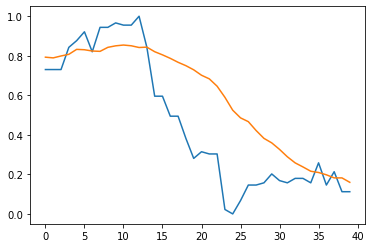

```python
import numpy as np
import matplotlib.pyplot as plt

plt.plot(np.array(range(40)), y_test)
plt.plot(np.array(range(40)), y_pred)
plt.show()
```